# Inference on Categorical Variables

Load libraries and data

```r
library(caret)
library(glmnet)
library(ROCR)
library(rebus)
library(broom)
source('tidy_data.R')
```

```r
load_wesnoth()
set.seed(123)
```

Let us first split the games in test and train set

```r
two_player_games <- two_player_games %>% filter(complete.cases(.))

idx <- createDataPartition(two_player_games$first_player_wins, p = 0.8, list = F)
train_set <- two_player_games[idx,]
test_set <- two_player_games[-idx,]

(dim(train_set))
```

```
## [1] 21828     4
```

```r
(dim(test_set))
```

```
## [1] 5457    4
```

It is sensible to create all features on the train set so we can accurately judge performance on the test set. We start by estimating the faction impact because we know already that the leaders are a perturbation to the faction choice.

```r
game_factions <- player_game_statistics %>%
    select(game_id, player_id, faction, leader)

aug_games <-  train_set %>%
    left_join(game_factions,
              by =c('game_id' = 'game_id','first_player_id'='player_id') ) %>%
    rename(fp_faction = faction, fp_leader = leader ) %>%
    left_join(game_factions,
              by =c('game_id' = 'game_id','second_player_id'='player_id') ) %>%
    rename(sp_faction = faction, sp_leader = leader)

faction_cleaned <- aug_games  %>%
    # Order the factors alphbetically, this way more data per faction is obtained
    mutate(factor_relation = as.character(fp_faction) <= as.character(sp_faction)) %>%
    mutate(faction_factor = if_else(factor_relation,
                                  str_c(fp_faction,' - ', sp_faction),
                                  str_c(sp_faction,' - ', fp_faction)),
           faction_win = if_else(factor_relation,
                                 first_player_wins,
                                 1-first_player_wins)) %>%
    select(faction_factor, faction_win)

faction_cleaned %>% head()
```

```
## # A tibble: 6 x 2
##   faction_factor       faction_win
##   <chr>                      <dbl>
## 1 Drakes - Loyalists             0
## 2 Northerners - Undead           0
## 3 Drakes - Loyalists             1
## 4 Northerners - Rebels           0
## 5 Northerners - Rebels           0
## 6 Drakes - Loyalists             0
```

We can now calculate the the $\alpha$ and $\beta$ variables of the bet distribution. We assume a maximum entropy prior and therefore choose $\alpha_0 = \beta_0 = 1$

```r
faction_cleaned <- faction_cleaned %>%
  group_by(faction_factor) %>%
  summarise(alph = 1 + sum(faction_win),
            bet = 1 + n() - sum(faction_win)) %>%
  ungroup()

faction_cleaned %>% head()
```

```
## # A tibble: 6 x 3
##   faction_factor             alph   bet
##   <chr>                     <dbl> <dbl>
## 1 Drakes - Drakes             125   113
## 2 Drakes - Khalifate            3     2
## 3 Drakes - Knalgan Alliance   737   519
## 4 Drakes - Loyalists          649   771
## 5 Drakes - Northerners        642   685
## 6 Drakes - Rebels             700   606
```

These values can be the new priors for the leader matchups. Let’s write a function that adds the parameter values to the faction matchup of a data frame.

```r
add_faction_parameters <- function(df,
                                   faction_lookup = faction_cleaned,
                                   statistics = player_game_statistics){
  # Select the relevant game statistics
  game_factions <- player_game_statistics %>%
      select(game_id, player_id, faction)

  # Add the faction information
  df <-  df %>%
    left_join(game_factions,
              by =c('game_id' = 'game_id','first_player_id'='player_id') ) %>%
    rename(fp_faction = faction) %>%
    left_join(game_factions,
              by =c('game_id' = 'game_id','second_player_id'='player_id') ) %>%
    rename(sp_faction = faction)



  df <- df %>%
    mutate(faction_relation = as.character(fp_faction) <= as.character(sp_faction),
          faction_factor = if_else(faction_relation,
                                      str_c(fp_faction,' - ', sp_faction),
                                      str_c(sp_faction,' - ', fp_faction))) %>%
    left_join(faction_lookup, on ='faction_factor') %>%
    mutate(faction_alph = if_else(faction_relation, alph, bet),
           faction_bet = if_else(faction_relation, bet, alph)) %>%
    # Set default values
    mutate(faction_alph = if_else(is.na(faction_alph), 1, faction_alph),
           faction_bet = if_else(is.na(faction_bet), 1, faction_bet)) %>%
    select(-c(alph,bet,fp_faction, sp_faction, faction_relation, faction_factor ))
  return(df)
}
```

Rather than adding the leaders as a perturbation to the expectations induced by the faction order, we can take this order as an independent factor. This is a Naive Bayes classifier approach, as the features are assumed to be independent, though they are not. Perhaps the final model will be able to adjust the weighting and consider interactions between the components.

```r
game_factions <- player_game_statistics %>%
    select(game_id, player_id, leader)

leader_cleaned <- train_set %>%
  left_join(game_factions,
              by =c('game_id' = 'game_id','first_player_id'='player_id') ) %>%
  rename(fp_leader = leader) %>%
  left_join(game_factions,
            by =c('game_id' = 'game_id','second_player_id'='player_id') ) %>%
  rename(sp_leader = leader) %>%
  mutate(leader_relation = as.character(fp_leader) <= as.character(sp_leader),
         leader_factor = if_else(leader_relation,
                                      str_c(fp_leader,' - ', sp_leader),
                                      str_c(sp_leader,' - ', fp_leader)),
         leader_win = if_else(leader_relation,
                                 first_player_wins,
                                 1-first_player_wins)) %>%
  group_by(leader_factor) %>%
  summarise(alph = 1 + sum(leader_win),
            bet = 1+n()-sum(leader_win)) %>%
  ungroup()

leader_cleaned %>% head()
```

```
## # A tibble: 6 x 3
##   leader_factor                 alph   bet
##   <chr>                        <dbl> <dbl>
## 1 Ancient Wose - Banebow           1     2
## 2 Bone Shooter - Bone Shooter      6     5
## 3 Bone Shooter - Dark Sorcerer    16    14
## 4 Bone Shooter - Deathblade       12    18
## 5 Bone Shooter - Drake Arbiter    24    24
## 6 Bone Shooter - Drake Flare      32    28
```

These factors can also be added to any data set via a function.

```r
add_leader_parameters <- function(df,
                                   leader_lookup = leader_cleaned,
                                   statistics = player_game_statistics){
  # Select the relevant game statistics
  game_factions <- player_game_statistics %>%
      select(game_id, player_id, leader)

  # Add the faction information
  df <-  df %>%
    left_join(game_factions,
              by =c('game_id' = 'game_id','first_player_id'='player_id') ) %>%
    rename(fp_leader = leader) %>%
    left_join(game_factions,
              by =c('game_id' = 'game_id','second_player_id'='player_id') ) %>%
    rename(sp_leader = leader)



  df <- df %>%
    mutate(leader_relation = as.character(fp_leader) <= as.character(sp_leader),
          leader_factor = if_else(leader_relation,
                                      str_c(fp_leader,' - ', sp_leader),
                                      str_c(sp_leader,' - ', fp_leader))) %>%
    left_join(leader_lookup, on ='leader_factor') %>%
    mutate(leader_alph = if_else(leader_relation, alph, bet),
           leader_bet = if_else(leader_relation, bet, alph)) %>%
    # Set default values
    mutate(leader_alph = if_else(is.na(leader_alph), 1, leader_alph),
           leader_bet = if_else(is.na(leader_bet), 1, leader_bet)) %>%
    select(-c(alph,bet,fp_leader, sp_leader, leader_relation, leader_factor ))
  return(df)
}
```

Next we do a similar thing for the maps. We group by map and who has the first move on the map. This is simplified, as the way the first player is defined in the data, she always has the first move. It is thus straightforward to aggregate the data

```r
map_cleaned <- two_player_games %>%
  left_join(game_info %>% select(game_id, map), by = c('game_id')) %>%
  group_by(map) %>%
  summarise(alph = 1+sum(first_player_wins, na.rm = T),
            bet = 1+n()-sum(first_player_wins, na.rm = T)) %>%
  ungroup()

map_cleaned %>% head()
```

```
## # A tibble: 6 x 3
##   map                                           alph   bet
##   <fct>                                        <dbl> <dbl>
## 1 aethermaw                                      171   135
## 2 arcanclave citadel                             105    86
## 3 arcanclave citadel - created by doc paterson     3     5
## 4 astral port                                    125   123
## 5 astral port - created by quetzalcoatl            8     5
## 6 autumn harvest                                   2     1
```

A function that adds this information

```r
add_map_parameters <- function(df,
                                   map_lookup = map_cleaned,
                                   statistics = game_info){


  # Add the faction information
  df <-  df %>%
    left_join(statistics %>% select(game_id, map), by = c('game_id'))

  print(colnames(df))

  df <- df %>%
    left_join(map_lookup, by =c('map'))%>%
    mutate(map_alph = alph,
           map_bet = bet) %>%
    # Set default values
    mutate(map_alph = if_else(is.na(map_alph), 1, map_alph),
           map_bet = if_else(is.na(map_bet), 1, map_bet)) %>%
    select(-c(alph,bet ))
  return(df)
}
```

Additionally we want to add the elo difference as a feature

```r
add_elo_diff <- function(df, game_info_tbl = game_info, elo_tbl = elos){

  # Calculate the Median of all players as a default choice
  median_elo <- elo_tbl %>% summarise(median_elo = median(elo)) %>% pull()

  # Create defaults by setting a very early date. This is the easiest to prevent
  #  Double counting
  default_elos <- df %>%
       select(first_player_id, second_player_id) %>%
       gather(key = player_position, value = player_id) %>%
       select(player_id) %>%
       distinct() %>%
       mutate(player_id = factor(player_id),
              elo = median_elo,
              date = ymd_hms('1900-01-01 01:01:01'))

  all_elos <- elos %>%
    group_by(player_id, date) %>%
    # Occasionally the same player has two elos for the same instance in time
    # This prevents that
    summarise(elo = median(elo)) %>%
    union_all(default_elos) %>%
    ungroup()

  df_with_features <- df %>%
    left_join(game_info_tbl %>% select(game_id, date) , by = c('game_id')) %>%
    left_join(all_elos %>% rename(elo_date = date), by = c('first_player_id'='player_id')) %>%
    group_by(game_id, first_player_id)%>%
    # Select for the latest Ranking
    filter(elo_date < date) %>%
    filter(elo_date == max(elo_date)) %>%
    rename(fp_elo = elo) %>%
    select(-elo_date) %>%
    left_join(all_elos %>% rename(elo_date = date), by = c('second_player_id'='player_id')) %>%
    group_by(game_id, second_player_id) %>%
    # Select for the latest Ranking
    filter(elo_date < date) %>%
    filter(elo_date == max(elo_date)) %>%
    rename(sp_elo = elo) %>%
    select(-elo_date)  %>%
    mutate(elo_diff = fp_elo - sp_elo,
           elo_diff = if_else(is.na(elo_diff), 0.0, elo_diff)) %>%
    select(-c(date, fp_elo, sp_elo)) %>%
    ungroup()
  return(df_with_features)
}
```

This function looks for the latest elo numbers before the game. This way it is made certain that the outcome of the game has not have an influence on the elo number, and therefore constitutes as feature creep. If no elo number for at least one of the players is found, the difference is set to zero. It might be more sensible to instead substitute a median value for the missing players. All the $\alpha$ and $\beta$ values are hard for a machine learning algorithm to learn. One way to help might be to transform the parameters into an average of the expected value for each feature; map, faction or leader; which is indexed by $i$
$$\mu_i = \frac{\alpha_i}{\alpha_i + \beta_i}.$$
Intuitively we would like to give an apriori higher weight to features with a larger sum $\alpha + \beta$, as for these situations there is more data. For each of the features and each of the observed cases we can locally weight the features with $\omega_i$,

$$\omega_i = \frac{\alpha_i + \beta_i}{\sum_j (\alpha_j+\beta_j)}$$

This can be combined into a function

```r
prepare_data <- function(df){
  df <- add_map_parameters(df)
  df <- add_faction_parameters(df)
  df <- add_leader_parameters(df)

  df <- df %>%
          mutate(leader_mu = leader_alph/(leader_alph+leader_bet),
                 faction_mu = faction_alph/(faction_alph+faction_bet),
                 map_mu = map_alph/(map_alph + map_bet),
                 leader_evid = leader_alph + leader_bet,
                 faction_evid = faction_alph + faction_bet,
                 map_evid = map_alph + map_bet,
                 sum_evid = leader_evid + faction_evid + map_evid,
                 leader_evid = leader_evid/sum_evid,
                 faction_evid = faction_evid/sum_evid,
                 map_evid = map_evid/sum_evid)



  df <- add_elo_diff(df)



  df <- df %>%
          select(game_id, leader_mu, leader_evid, faction_mu, faction_evid,
                 map_mu, map_evid, elo_diff)
  return(df)
}
```

```r
train_set %>%
  head(10) %>%
  prepare_data()
```

```
## [1] "game_id"           "first_player_id"   "second_player_id"
## [4] "first_player_wins" "map"
```

```
## # A tibble: 10 x 8
##    game_id leader_mu leader_evid faction_mu faction_evid map_mu map_evid
##      <int>     <dbl>       <dbl>      <dbl>        <dbl>  <dbl>    <dbl>
##  1       1     0.5       0.0262       0.457        0.321  0.546    0.653
##  2       2     0.467     0.0205       0.481        0.441  0.531    0.539
##  3       3     0.519     0.0148       0.457        0.390  0.530    0.596
##  4       4     0.571     0.00999      0.464        0.419  0.502    0.571
##  5       5     0.476     0.0190       0.464        0.442  0.526    0.539
##  6       6     0.432     0.00851      0.457        0.327  0.546    0.665
##  7       8     0.528     0.0214       0.519        0.384  0.502    0.595
##  8       9     0.453     0.0141       0.516        0.292  0.513    0.694
##  9      10     0.548     0.0101       0.402        0.317  0.569    0.673
## 10      11     0.432     0.00851      0.457        0.327  0.546    0.665
## # ... with 1 more variable: elo_diff <dbl>
```

### Training the Model

A very simple model could be the averaged expectated values of the categorical inferences.

```r
train_features <- train_set %>%
                prepare_data() %>%
                mutate(prediction = leader_mu*leader_evid + faction_mu*faction_evid + map_mu *  map_evid) %>%
                inner_join(train_set %>% select(game_id, first_player_wins) , by = c('game_id'))
```

```
## [1] "game_id"           "first_player_id"   "second_player_id"
## [4] "first_player_wins" "map"
```

```r
auc(train_set$first_player_wins, train_features$prediction )
```

```
## [1] 0.5603708
```

It seems that the pure aggregated feature is not that predictive. A simple model on the elo_diff might be better.

```r
elo_model <- train(factor(first_player_wins)~elo_diff,
                   method = 'glm',
                   family = 'binomial',
                   data = train_features)
```

Let us see how predictions work on an unseen test set.

```r
test_features <- test_set %>%
                    prepare_data()
```

```
## [1] "game_id"           "first_player_id"   "second_player_id"
## [4] "first_player_wins" "map"
```

```r
test_features$prediction <- predict(elo_model, newdata = test_features, type = 'prob')[,2]
```

```r
auc(test_set$first_player_wins, test_features$prediction)
```

```
## [1] 0.7089708
```

The elo diff is much more predictive on unseen data! If we combine these, we might be able to get stronger predictive performance.

We can try to improve the model by using a different ML algorithm,xg-boost. First we generate a data partition of the train set, so we can tune the model parameters via cross-validation.

```r
train_features <- train_features %>%
  select(-prediction, -game_id ) %>%
  mutate(first_player_wins = factor(first_player_wins))

cv_idx <- createFolds(train_features$first_player_wins, k = 5)
```

And a train control object

```r
train_control <- trainControl(
  method = "cv",
  index = cv_idx,
  verboseIter = FALSE,
  allowParallel = TRUE
)
```

For the initial training, we can choose a parameter set

```r
train_grid <- expand.grid(
  nrounds = 1000,
  max_depth = 6,
  eta = 0.1,
  gamma = 0,
  colsample_bytree = 1,
  min_child_weight = 1,
  subsample = 1
)
```

```r
xgb_model <- train(first_player_wins ~ .,
                  method = 'xgbTree',
                  data = train_features,
                  tuneGrid = train_grid,
                  trControl = train_control,
                  verbose = T)
```

```r
predictions <- predict(xgb_model, newdata = test_features, type = 'prob')[,2]
auc(test_set$first_player_wins, predictions)
```

```
## [1] 0.6823473
```

```r
tuneplot <- function(x, probs = .90) {
  ggplot(x) +
    coord_cartesian(ylim = c(quantile(x$results$Accuracy, probs = probs), min(x$results$Accuracy))) +
    theme_bw()
}
```

```r
train_grid2 <- expand.grid(
  nrounds = seq(from = 200, to = 1000, by = 50),
  max_depth = c(2, 3, 4),
  eta = c(0.025, 0.05, 0.1),
  gamma = 0,
  colsample_bytree = 1,
  min_child_weight = 1,
  subsample = 1
)
```

```r
xgb_model2 <- train(first_player_wins ~ .,
                  method = 'xgbTree',
                  data = train_features,
                  tuneGrid = train_grid2,
                  trControl = train_control,
                  verbose = T)
```

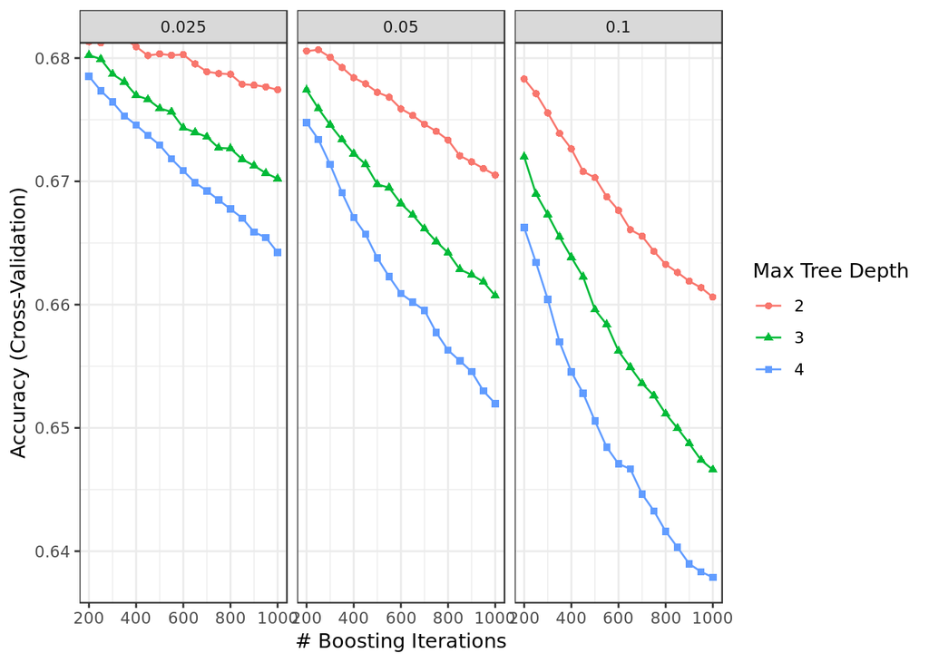

```r
tuneplot(xgb_model2)
```

The output does not work. But it seems that overfitting already happened, so it makes sense to look for simpler models.

```r
predictions <- predict(xgb_model2, newdata = test_features, type = 'prob')[,2]
auc(test_set$first_player_wins, predictions)
```

```
## [1] 0.7118245
```

```r
train_grid3 <- expand.grid(
  nrounds = seq(from = 10, to = 1000, by = 10),
  max_depth = c(1, 2, 3),
  eta = c(0.01,0.025),
  gamma = 0,
  colsample_bytree = 1,
  min_child_weight = 1,
  subsample = 1
)
```

```r
xgb_model3 <- train(first_player_wins ~ .,
                  method = 'xgbTree',
                  data = train_features,
                  tuneGrid = train_grid3,
                  trControl = train_control,
                  verbose = T)
```

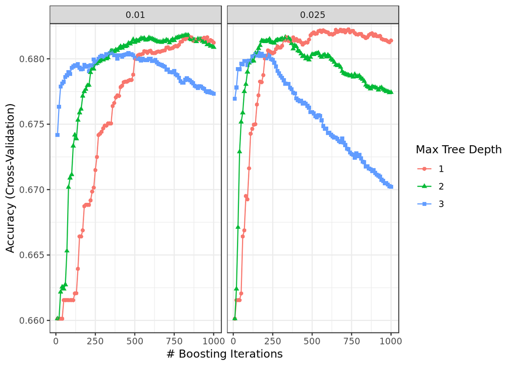

```r
tuneplot(xgb_model3)
```

```r
predictions <- predict(xgb_model3, newdata = test_features, type = 'prob')[,2]
auc(test_set$first_player_wins, predictions)
```

```
## [1] 0.7122853
```

Performance has not really improved. The fact that the tuning prefers the shallowest models and works better at very slow learning rates suggests that the features are already pretty informative as they are and model finetuning will not improve that so much. Interestingly, when training a simple logistic regression, we get a similar performance.

```r
lr_model <- train(factor(first_player_wins) ~ .,
             data      = train_features    ,
             method    = "glm"    ,
             family    = binomial ,
             trControl = train_control)
predictions <- predict(lr_model, newdata = test_features, type = 'prob')[,2]
auc(test_set$first_player_wins, predictions)
```

```
## [1] 0.7129862
```

From the summary it is clear that the $\mu$ values are made good use of, whereas the evidences are more or less completely neglected (not sure where the `NA`s come from).

```r
summary(lr_model)
```

```
##
## Call:
## NULL
##
## Deviance Residuals:
##     Min       1Q   Median       3Q      Max
## -2.5716  -1.0070   0.4718   0.9677   2.5265
##
## Coefficients: (1 not defined because of singularities)
##                Estimate Std. Error z value Pr(>|z|)
## (Intercept)  -4.783e+00  2.767e-01 -17.288  < 2e-16 ***
## leader_mu     4.484e+00  1.834e-01  24.450  < 2e-16 ***
## leader_evid  -2.633e-02  1.653e+00  -0.016  0.98730
## faction_mu    8.885e-01  3.422e-01   2.596  0.00942 **
## faction_evid  5.582e-02  9.768e-02   0.571  0.56767
## map_mu        4.158e+00  4.248e-01   9.789  < 2e-16 ***
## map_evid             NA         NA      NA       NA
## elo_diff      3.094e-03  5.877e-05  52.640  < 2e-16 ***
## ---
## Signif. codes:  0 '***' 0.001 '**' 0.01 '*' 0.05 '.' 0.1 ' ' 1
##
## (Dispersion parameter for binomial family taken to be 1)
##
##     Null deviance: 30181  on 21827  degrees of freedom
## Residual deviance: 25588  on 21821  degrees of freedom
## AIC: 25602
##
## Number of Fisher Scoring iterations: 3
```